# Linked List

Linked list adalah struktur data fundamental dalam ilmu komputer. Fungsi utamanya adalah memungkinkan operasi penyisipan dan penghapusan yang lebih efisien dibandingkan dengan array . Seperti array, linked list juga digunakan untuk mengimplementasikan struktur data lain seperti stack, queue, dan deque.

Linked list adalah jenis struktur data linear di mana setiap item tidak selalu berada di lokasi yang berdekatan. Setiap item disebut node dan dihubungkan satu sama lain menggunakan link.

Sebuah node berisi dua hal, pertama adalah data dan kedua adalah tautan yang menghubungkannya dengan node lain. Node pertama disebut node kepala dan kita dapat menelusuri seluruh daftar menggunakan tautan kepala dan berikutnya ini.

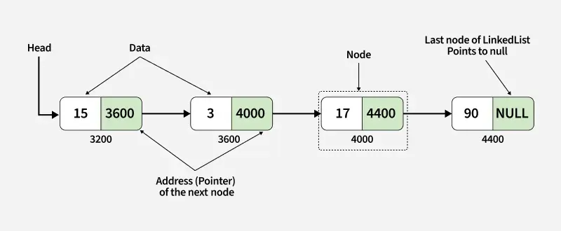

### Perbandingan antara Linked List dan Array.

#### Link List:

- Struktur Data: Tidak Berurutan
- Alokasi Memori: Biasanya dialokasikan satu per satu ke masing-masing elemen.
- Penyisipan/Penghapusan: Efisien
- Akses: Berurutan

#### Array:

- Struktur Data: Berurutan
- Alokasi Memori: Biasanya dialokasikan ke seluruh array.
- Penyisipan/Penghapusan: Tidak Efisien
- Akses: Acak

## Singly Linked List

Linked list tunggal adalah struktur data fundamental, terdiri dari node di mana setiap node berisi field data dan referensi ke node berikutnya dalam linked list. Node berikutnya setelah node terakhir adalah null , yang menunjukkan akhir dari list. Linked list mendukung operasi penyisipan dan penghapusan yang efisien.

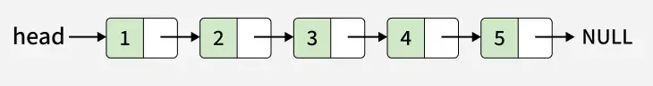

#### Memahami Struktur Node

Dalam linked list tunggal, setiap node terdiri dari dua bagian: data dan pointer ke node berikutnya. Struktur ini memungkinkan node untuk dihubungkan secara dinamis, membentuk urutan seperti rantai.

```python
# Definition of a Node in a singly linked list
class Node:
    def __init__(self, data):

        # Data part of the node
        self.data = data
        self.next = None
```

Dalam contoh ini, kelas Node berisi field data integer ( data ) untuk menyimpan informasi dan pointer ke Node lain ( next ) untuk membuat tautan ke node berikutnya dalam daftar.

Buat node pertama

- Alokasikan memori untuk node pertama dan simpan data di dalamnya.
- Tandai node ini sebagai head.

Buat node kedua

- Alokasikan memori untuk node kedua dan simpan data di dalamnya.
- Hubungkan node pertama di sebelahnya dengan node baru ini.

Buat simpul ketiga

- Alokasikan memori untuk node ketiga dan simpan data di dalamnya.
- Hubungkan node kedua di sebelah node ini.
- Atur nilai next-nya menjadi NULL untuk memastikan bahwa nilai next dari nilai terakhir adalah NULL.

```python
# constructor to initialize a new node with data
class Node:
    def __init__(self, new_data):
        self.data = new_data
        self.next = None

# Create the first node (head of the list)
head = Node(10)

# Link the second node
head.next = Node(20)

# Link the third node
head.next.next = Node(30)

# Link the fourth node
head.next.next.next = Node(40)

# printing linked list
temp = head
while temp is not None:
    print(temp.data, end=" ")
    temp = temp.next
```

```
10 20 30 40
```

Keuntungan:

- Ukuran dinamis (tidak ada batasan tetap seperti pada array)
- Penyisipan dan penghapusan yang efisien di awal dan akhir. Kami juga memiliki penyisipan di tengah yang efisien jika kami memiliki referensi atau penunjuk ke node setelah node yang perlu kami sisipkan.
- Dapat mengimplementasikan struktur data kompleks seperti stack, queue, dan graph.

Kerugian

- Memori tambahan diperlukan untuk menyimpan pointer.
- Tidak ada akses langsung/acak (membutuhkan penelusuran)
- Tidak ramah cache (tidak disimpan dalam memori yang berdekatan)

## Doubly Linked List

Daftar berantai ganda (doubly linked list) adalah struktur data yang lebih kompleks daripada daftar berantai tunggal (singly linked list), tetapi menawarkan beberapa keunggulan. Keunggulan utama dari daftar berantai ganda adalah memungkinkan penelusuran daftar yang efisien dalam kedua arah. Hal ini karena setiap node dalam daftar berisi penunjuk ke node sebelumnya dan penunjuk ke node berikutnya. Ini memungkinkan penyisipan dan penghapusan node dari daftar dengan cepat dan mudah, serta penelusuran daftar yang efisien dalam kedua arah.

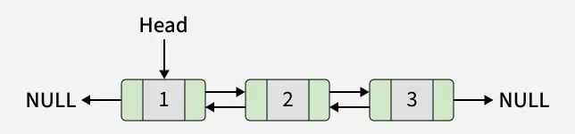

#### Representasi Daftar Berantai Ganda dalam Struktur Data

Dalam sebuah struktur data, sebuah linked list ganda direpresentasikan menggunakan node yang memiliki tiga field:

1. Data
2. Penunjuk ke node berikutnya ( next )
3. Penunjuk ke node sebelumnya ( prev )

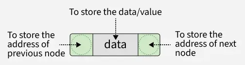

#### Definisi Node

Berikut adalah cara representasi umum sebuah node dalam Doubly Linked List:

```python
class Node:

    def __init__(self, data):
        # To store the value or data.
        self.data = data

        # Reference to the previous node
        self.prev = None

        # Reference to the next node
        self.next = None
```

[output not shown]

#### Membuat Linked List Ganda dengan 4 Node

Buat node kepala.

- Alokasikan sebuah node dan tetapkan head-nya. Nilai prev dan next-nya harus null/None.

Buat node berikutnya dan hubungkan ke head.

- head.next = new Node(value2)
- head.next.prev = head

Buat node selanjutnya dengan cara yang sama.

- Untuk node ketiga:

=> head.next.next = new Node(value3) => head.next.next.prev = head.next

- Ulangi hingga Anda memiliki node yang dibutuhkan

Pastikan next pada tail bernilai null. Node terakhir yang Anda buat harus memiliki next == null.

Tetapkan/lacak kepala (dan opsional ekor). Gunakan kepala untuk mengakses daftar dari depan. Melacak penunjuk ekor menyederhanakan penambahan.

```python
class Node:
    def __init__(self, value):
        self.data = value
        self.prev = None
        self.next = None

if __name__ == "__main__":
    # Create the first node (head of the list)
    head = Node(10)

    # Create and link the second node
    head.next = Node(20)
    head.next.prev = head

    # Create and link the third node
    head.next.next = Node(30)
    head.next.next.prev = head.next

    # Create and link the fourth node
    head.next.next.next = Node(40)
    head.next.next.next.prev = head.next.next

    # Traverse the list forward and print elements
    temp = head
    while temp is not None:
        print(temp.data, end="")
        if temp.next is not None:
            print(" <-> ", end="")
        temp = temp.next
```

```
10 <-> 20 <-> 30 <-> 40
```

Keunggulan dari Double Linked List

- Penelusuran Dua Arah - Anda dapat menelusuri ke depan (menggunakan next) maupun ke belakang (menggunakan prev).
- Penghapusan yang Efisien - Dengan diberikan pointer ke sebuah node, Anda dapat menghapusnya dalam waktu O(1) (tidak perlu melakukan traversal dari head), karena Anda dapat memperbarui prev dan next.
- Penyisipan di Kedua Ujung - Penyisipan di bagian kepala atau ekor efisien karena Anda dapat memperbarui kedua arah dengan mudah.
- Fitur Deque/Navigasi yang Mudah Diimplementasikan - Berguna untuk fungsi undo/redo, riwayat browser, dan navigasi daftar putar musik, di mana pergerakan maju dan mundur diperlukan.

Kelemahan dari Daftar Berantai Ganda

- Memori Tambahan Per Node - Setiap node membutuhkan pointer tambahan (prev), sehingga DLL lebih boros memori daripada linked list tunggal.
- Implementasi yang Lebih Kompleks - Baik prev maupun next harus ditangani dengan hati-hati selama penyisipan dan penghapusan, yang meningkatkan kemungkinan kesalahan (tautan rusak, masalah penunjuk null).
- Operasi Lebih Lambat Karena Overhead - Manipulasi pointer tambahan selama penyisipan/penghapusan menyebabkan overhead yang sedikit lebih besar dibandingkan dengan linked list tunggal.
- Tidak Ramah Cache - Seperti halnya linked list tunggal, node tersebar di memori, sehingga penelusuran mungkin lebih lambat dibandingkan dengan array karena lokalisasi referensi yang buruk.